# OCN683_Distributions_HW4

ʻAʻaliʻi Kelling

2025-02-11

## **Homework 4 - Distributions for surviving copepods and abundant tang**

## **Background**

The file ‘dam_acartia_survival_subset.csv’ contains some data on the survival of the copepod Acartia tonsa, from a study conducted by Hans Dam and colleagues. In experimental cultures the survival of copepods was tracked from the nauplius 1 stage to the copepodid 6 stage. The data used here is a subset: only the copepods reared at temperature 18ºC, and with survival measured at day 14. The column ‘nx’ is the number of surviving copepods, out of 25, on day 14. We are going to investigate the distribution of this subset of the data.

## Loading datasets

```
##
## arm (Version 1.14-4, built: 2024-4-1)
```

```
## Working directory is /Users/aaliikelling/Desktop/Git Hub Repositories/OCN683/HW4
```

```
##
##
## here() starts at /Users/aaliikelling/Desktop/Git Hub Repositories/OCN683
##
##
```

```
## Caution: You lose important information if you filter this package's results.
## See '? untidy'
```

```
## 'data.frame':    91 obs. of  11 variables:
##  $ X         : int  24 40 120 200 248 264 280 296 312 328 ...
##  $ Generation: int  0 0 0 0 0 0 0 0 0 0 ...
##  $ Treatment : int  1 1 1 2 2 2 2 2 2 2 ...
##  $ Temp      : int  18 18 18 18 18 18 18 18 18 18 ...
##  $ pH        : num  8.2 8.2 8.2 7.5 7.5 7.5 7.5 7.5 7.5 7.5 ...
##  $ Rep       : int  1 1 3 1 2 2 2 3 3 3 ...
##  $ Beak      : int  2 3 2 1 1 2 3 1 2 3 ...
##  $ time      : int  14 14 14 14 14 14 14 14 14 14 ...
##  $ nx        : int  10 6 13 20 15 17 16 19 17 16 ...
##  $ lx        : num  0.4 0.24 0.52 0.8 0.6 0.68 0.64 0.76 0.68 0.64 ...
##  $ ni        : int  25 25 25 25 25 25 25 25 25 25 ...
```

```
## 'data.frame':    1373 obs. of  60 variables:
##  $ X.1                 : int  121734 121735 121736 121737 121738 121739 121740 121741 121742 121743 ...
##  $ X                   : int  121734 121735 121736 121737 121738 121739 121740 121741 121742 121743 ...
##  $ commonname          : chr  "Yellow tang" "Yellow tang" "Yellow tang" "Yellow tang" ...
##  $ time                : chr  "2013-08-03T00:00:00Z" "2013-08-03T00:00:00Z" "2013-08-03T00:00:00Z" "2013-08-03T00:00:00Z" ...
##  $ latitude            : num  20.2 20.2 20.2 20.2 20.2 ...
##  $ longitude           : num  -156 -156 -156 -156 -156 ...
##  $ region_name         : chr  "Main Hawaiian Islands" "Main Hawaiian Islands" "Main Hawaiian Islands" "Main Hawaiian Islands" ...
##  $ island              : chr  "Hawaii" "Hawaii" "Hawaii" "Hawaii" ...
##  $ site                : chr  "HAW-431" "HAW-431" "HAW-397" "HAW-397" ...
##  $ reef_zone           : chr  "Forereef" "Forereef" "Forereef" "Forereef" ...
##  $ depth_bin           : chr  "Mid" "Mid" "Deep" "Deep" ...
##  $ sitevisitid         : int  5930 5930 5929 5929 5923 5923 5924 5924 5934 5934 ...
##  $ date_               : chr  "2013-08-03T00:00:00Z" "2013-08-03T00:00:00Z" "2013-08-03T00:00:00Z" "2013-08-03T00:00:00Z" ...
##  $ obs_year            : int  2013 2013 2013 2013 2013 2013 2013 2013 2013 2013 ...
```

[output cut: 46 more lines]

## **Task 1**

(1 – 3 points) First plot a histrogram of the data, using the discrete.histogram() function from the package ‘arm’. This function is better than standard histogram functions for our purposes, because the standard binning algorithms makes it hard to see what is happening at the ends of the distribution.

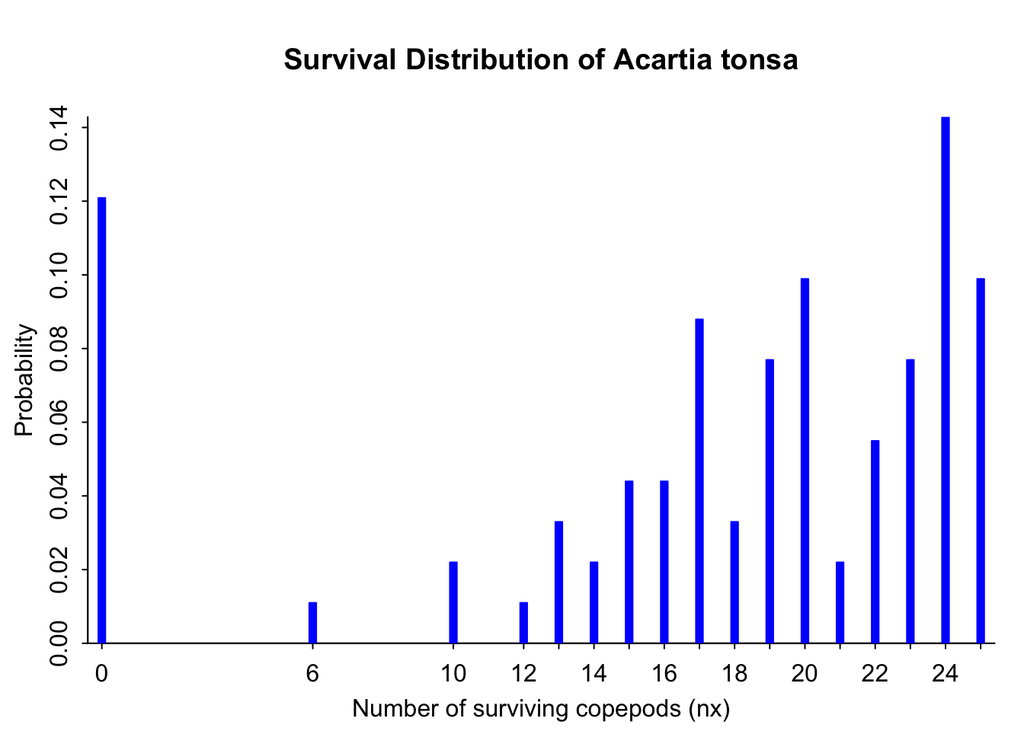

```r
#make a histogram of the number of survivors per plot
 discrete.histogram(cope$nx,
                    main = "Survival Distribution of Acartia tonsa",
                   xlab = "Number of surviving copepods (nx)")
```

## **Task 2**

(2 – 4 points) Now calculate the mean and the variance of the number of survivors. This kind of data could potentially be modelled as a binomial distribution. Based on the formula for the binomial distribution (it is in the lecture notes, or on Wikipedia), what should the variance be, if the data were actually binomially distributed, given the mean number of survivors we observe?

```r
#Calculting the mean and variance of the survival data
copestats <- cope %>%
  summarise(
    mean = mean(nx), #Mean = 17.4
    variance = sd(nx) #Variance = 7.6
  )
copestats
```

```
##       mean variance
## 1 17.38462 7.622728
```

```r
# Total copepods per trial
cope_total <- 25

# Estimated survival probability
p_survival <- copestats$mean / cope_total

# Expected variance under a binomial model
binom_var <- cope_total * p_survival * (1 - p_survival)
binom_var
```

```
## [1] 5.295621
```

## **Task 3**

(3 – 4 points) Use the function rbinom() to simulate random draws from a binomial distribution that has the same probability of survival as the observed copepod data. Draw the same number of values as are present in the observed data. Calculate the mean and the variance of the number of survivors. Plot a histogram of your randomly drawn values. Now repeat this four more times – you will have a total five histograms as well as five means and variances. Describe how your simulated binomial data differs from the observed data. Can you imagine reasons why the two distributions might be different?

```r
# Number of observations (same as in the dataset)
num_obs <- length(cope$nx)

# Define number of simulations
n_simulations <- 4

# Create empty lists to store results
simulated_data <- list()
simulated_means <- numeric(n_simulations)  # Store means
simulated_variances <- numeric(n_simulations)  # Store variances

# Set up the graphics area for 6 histograms (1 observed + 4 simulations)
par(mfrow = c(2, 3))

# Plot the histogram for observed data first
discrete.histogram(cope$nx, col = "red", main = "Observed Data", freq = FALSE)

# Loop to generate 5 different simulated datasets
set.seed(123)  # For reproducibility
for (i in 1:n_simulations) {
  # Generate binomial survival data for the same number of observations as the dataset
  simulated_data[[i]] <- rbinom(num_obs, cope_total, p_survival)

  # Compute mean and variance for the simulated dataset
  simulated_means[i] <- mean(simulated_data[[i]])
  simulated_variances[i] <- sd(simulated_data[[i]])

  # Plot histogram for each simulation
  discrete.histogram(simulated_data[[i]], col = "skyblue",
                     main = paste("Simulation", i), freq = FALSE)
}

# Five simulated means and variances to their observed values
mean(cope$nx)
```

```
## [1] 17.38462
```

```r
simulated_means
```

```
## [1] 17.36264 17.38462 17.26374 17.49451
```

```r
sd(cope$nx)
```

```
## [1] 7.622728
```

```r
simulated_variances
```

```
## [1] 2.331030 1.942331 2.215276 2.500549
```

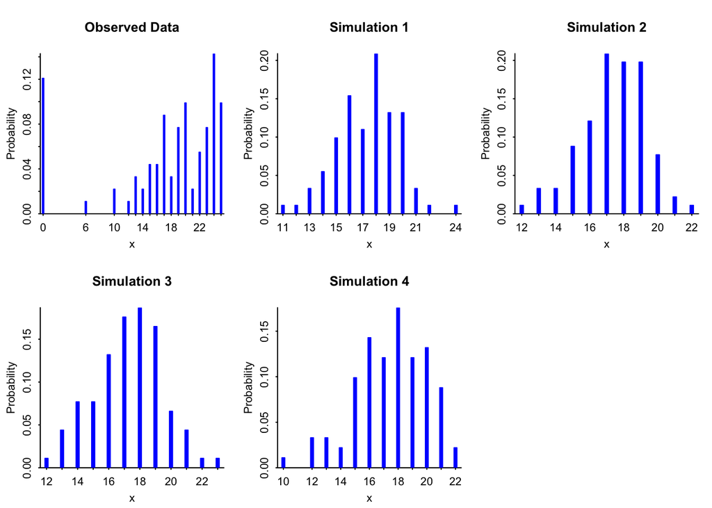

## **Task 4**

(4 – 4 points) Now load the package VGAM, which has functions for the beta-binomial distribution. This distribution is similar to the binomial, in that it models success/failure of a ‘trial’, but it allows the probability of success to vary across trials. This extra variability is controlled by the parameter ‘rho’. Use trial and error, with the function rbetabinom, to find a value of rho that creates a distribution that looks similar to the observed copepod data. A value of 0 for rho produces a binomial distribution, while increasing values of rho between 0 and 1 lead to more variability in the data. Display the results of your trial and error simulations, and report what value of rho you think best corresponds to the observed data.

```r
library(VGAM)
```

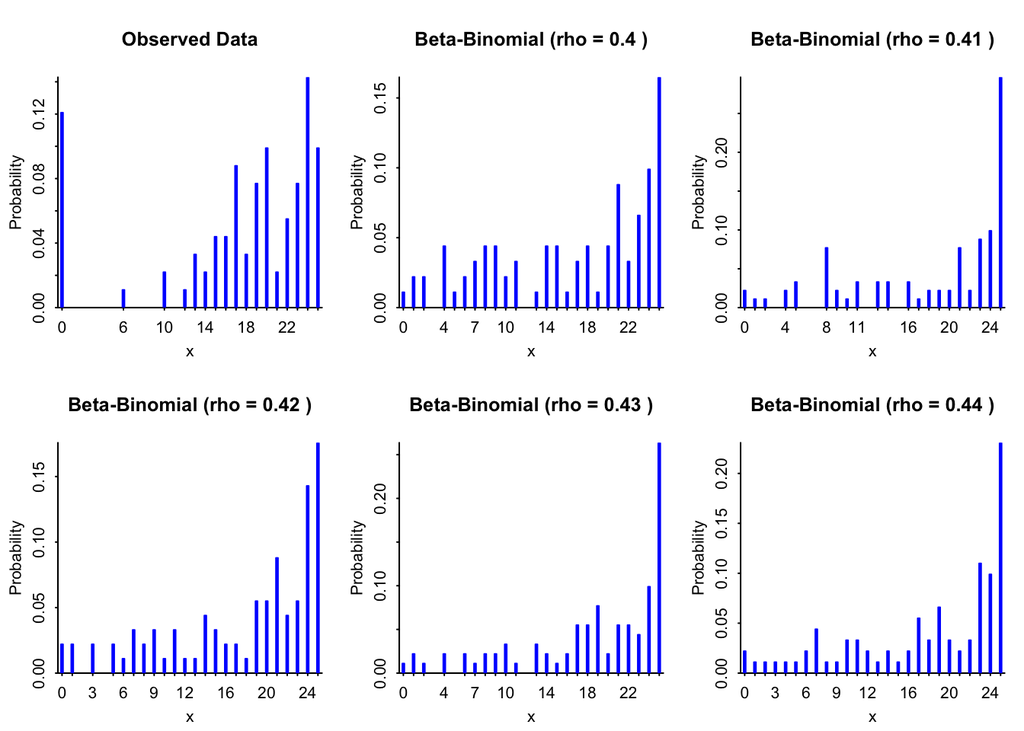

```r
# Define rho values to test (0 = binomial, increasing values = more variability)
rho_values <- c(0.40, 0.41, 0.42, 0.43, 0.44, 0.45)

# Create empty lists to store results
simulated_data <- list()
simulated_means <- numeric(length(rho_values))  # Store means
simulated_variances <- numeric(length(rho_values))  # Store variances

# Set up the graphics area for 6 histograms (1 observed + 5 simulations)
par(mfrow = c(2, 3))

# Plot the histogram for observed data first
discrete.histogram(cope$nx, col = "red", main = "Observed Data", freq = FALSE)

# Loop to generate 5 different simulated datasets using Beta-Binomial distribution
set.seed(123)  # For reproducibility
for (i in 1:length(rho_values)) {
  # Generate beta-binomial survival data for the same number of observations as the dataset
  simulated_data[[i]] <- rbetabinom(num_obs, cope_total, p_survival, rho_values[i])

  # Compute mean and variance for the simulated dataset
  simulated_means[i] <- mean(simulated_data[[i]])
  simulated_variances[i] <- sd(simulated_data[[i]])

  # Plot histogram for each simulation
  discrete.histogram(simulated_data[[i]], col = "skyblue",
                     main = paste("Beta-Binomial (rho =", rho_values[i], ")"), freq = FALSE)
}
```

```r
# Five simulated means and variances to their observed values
mean(cope$nx)
```

```
## [1] 17.38462
```

```r
simulated_means
```

```
## [1] 16.60440 18.34066 17.79121 18.58242 18.01099 17.54945
```

```r
sd(cope$nx)
```

```
## [1] 7.622728
```

```r
simulated_variances
```

```
## [1] 7.686755 7.632125 7.356806 6.992164 7.388421 8.384196
```

[figure not shown]